# t-Tests

Class Activity

Andrew Seaman

2025-May-14

# Questions:

## Q1.

> *Explain to a peer what information you can find under the “Overview”, “R Instructions”, and “Explanation” tabs for each of the three t-tests on the t-Tests page.*

t-Tests:

1. **One Sample t Test**
2. **Paired Samples t Test**
3. **Independent Samples t Test**

Tab content description:

- **Overview:** Questions, requirements, and hypotheses.
- **R Instructions:** Test function and parameters.
- **Explanation:** Summary of how to interpret test results.

## Q2.

> *Use the R Instructions to perform a One Sample t-Test of the following hypotheses using the KidsFeet data set. You should get a test statistic of t = -15.532.*

$$H_0 : \mu_{\text{length of kids' feet}} = 28 \text{ cm}$$
$$H_a : \mu_{\text{length of kids' feet}} \neq 28 cm$$

Yes, I can. Below are the results of a One Sample t test

```r
# a. One sample t test
pander(t.test(KidsFeet$length, mu = 28, alternative="two.sided", conf.level=.95))
```

One Sample t-test: `KidsFeet$length`

| Test statistic | df | P value | Alternative hypothesis | mean of x |
| --- | --- | --- | --- | --- |
| -15.53 | 38 | 4.806e-18 * * * | two.sided | 24.72 |

## Q3.

> *Use the R Instructions to perform a Paired-Samples t-Test of the following hypotheses using the KidsFeet data set. You should get a test statistic of t = -11.529.*

$$H_0: \mu_{\text{length} - 3 \cdot \text{width}} = 0$$
$$H_a: \mu_{\text{length} - 3 \cdot \text{width}} \neq 0$$

Yes, I can. Below are the results of a Paired Samples t Test.

```r
# a. Paired samples t test
pander(t.test(KidsFeet$length - 3 * KidsFeet$width, mu = 0))
```

One Sample t-test: `KidsFeet$length - 3 * KidsFeet$width`

| Test statistic | df | P value | Alternative hypothesis | mean of x |
| --- | --- | --- | --- | --- |
| -11.53 | 38 | 5.668e-14 * * * | two.sided | -2.254 |

## Q4.

> *Use the R Instructions to perform an Independent Samples t-Test of the following hypotheses using the KidsFeet data set. You should get a test statistic of t = 1.9174.*

$$H_0: \mu_\text{Boys foot length} - \mu_\text{Girls foot length} = 0$$
$$H_a: \mu_\text{Boys foot length} - \mu_\text{Girls foot length} \neq 0$$

Yes, I can. Below are the results of a Independent Samples t-Test.

```r
# a. Independent samples t test (assume variance)
pander(t.test(length ~ sex, data = KidsFeet, var.equal = FALSE))
```

Welch Two Sample t-test: `length` by `sex` (continued below)

| Test statistic | df | P value | Alternative hypothesis | mean in group B |
| --- | --- | --- | --- | --- |
| 1.917 | 36.27 | 0.06308 | two.sided | 25.1 |

| mean in group G |
| --- |
| 24.32 |

## Q5.

> *Discuss with a peer why we create Q-Q Plots and check sample sizes when performing t Tests.*

There are certain requirements that must be met to use a t test.

1. **One Sample t Test**
   - The sample is representative of the population. (Having a simple random sample is the best way to do this.)
   - The sampling distribution of the sample mean 𝑥¯ can be assumed to be normal. This is a safe assumption when either (a) the population data can be assumed to be normally distributed using a Q-Q Plot or (b) the size of the sample (n) that was taken from the population is large (at least n > 30, but “large” really depends on how badly the data is skewed).
2. **Paired Samples t Test**
   - The sample of differences is representative of the population differences.
   - The sampling distribution of the sample mean of the differences 𝑑¯(𝑥¯ of the differences) can be assumed to be normal. (This second requirement can be assumed to be satisfied when (a) the differences themselves can be assumed to be normal from a Q-Q Plot, or (b) when the sample size 𝑛of the differences is large.)
3. **Independent Samples t Test**
   - Both samples are representative of the population. (Simple random samples are the best way to do this.)
   - The sampling distribution of the difference of the sample means (𝑥¯1−𝑥¯2) can be assumed to be normal. (This is a safe assumption when the sample size of each group is 30 or greater or when the population data from each group can be assumed to be normal with a Q-Q Plot.)

## Q6.

> *Discuss with a peer what an appropriate graphic would be for each of the three t tests you performed above.*

#### One Sample t-Test

- *Best graphic:* Histogram or dotplot with reference line (population mean)

$$H_0 : \mu_{\text{length of kids' feet}} = 28 \text{ cm}$$
$$H_a : \mu_{\text{length of kids' feet}} \neq 28 cm$$

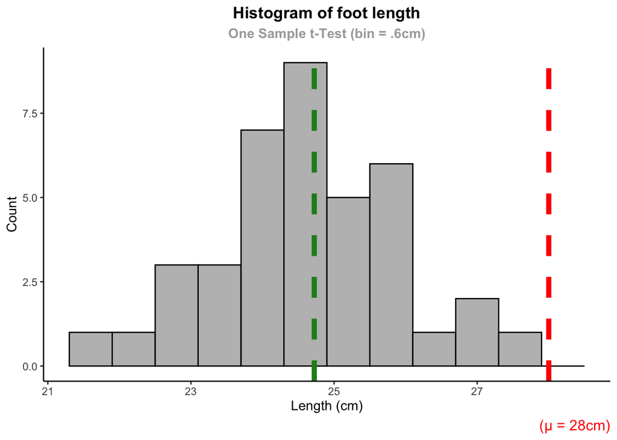

```r
(
  ggplot(KidsFeet)
    + geom_histogram(aes(x=length), fill="gray", color="black", binwidth=.6)
    + geom_vline(xintercept=28, color="red",  linetype="dashed", linewidth=2)
    + geom_vline(xintercept=mean(KidsFeet$length), color="forestgreen", linetype="dashed", linewidth=2)
    + labs(
        title="Histogram of foot length",
        subtitle="One Sample t-Test (bin = .6cm)",
        caption="(µ = 28cm)",
        x="Length (cm)",
        y="Count"
    )
    + theme_classic()
    + theme(
        plot.title = element_text(hjust=.5, face="bold"),
        plot.subtitle = element_text(hjust=.5, face="bold", color="darkgray"),
        plot.caption = element_text(color="red", size=12)
    )
)
```

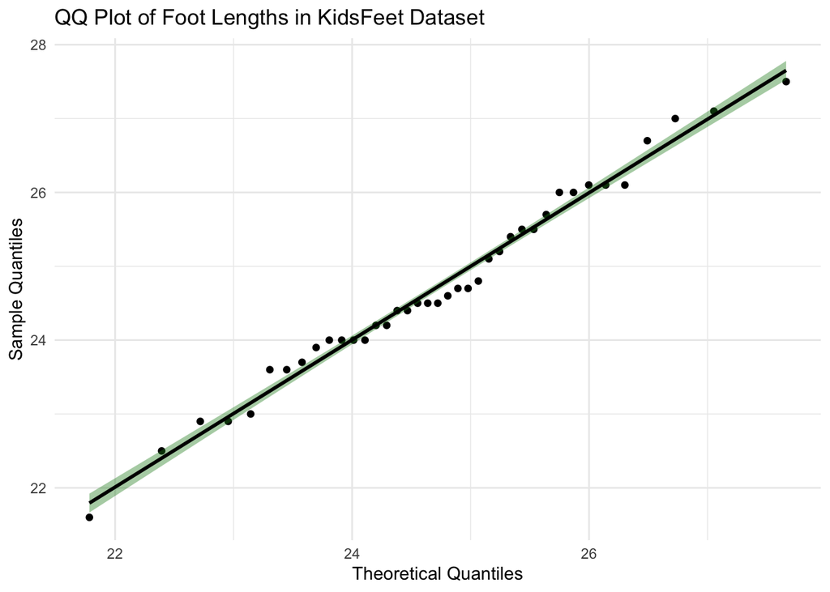

```r
# a. QQ plot for One Sample t Test

# Compute theoretical quantiles & confidence band manually
qq_data <- KidsFeet %>%
  mutate(sample_quantiles = sort(length),
         theoretical_quantiles = qnorm(ppoints(length), mean(length), sd(length))) %>%
  arrange(theoretical_quantiles)

# Plot QQ plot with shaded confidence band
ggplot(qq_data, aes(x = theoretical_quantiles, y = sample_quantiles)) +
  geom_point() +  # QQ points
  geom_smooth(method = "lm", se = TRUE, color = "black", fill = "forestgreen") +  # Shaded confidence band
  labs(title = "QQ Plot of Foot Lengths in KidsFeet Dataset",
       x = "Theoretical Quantiles",
       y = "Sample Quantiles") +
  theme_minimal()
```

#### Paired Samples t-Test

- *Best graphic:* Dot-and-line plot (paired differences) or histogram of the differences

$$H_0: \mu_{\text{length} - 3 \cdot \text{width}} = 0$$
$$H_a: \mu_{\text{length} - 3 \cdot \text{width}} \neq 0$$

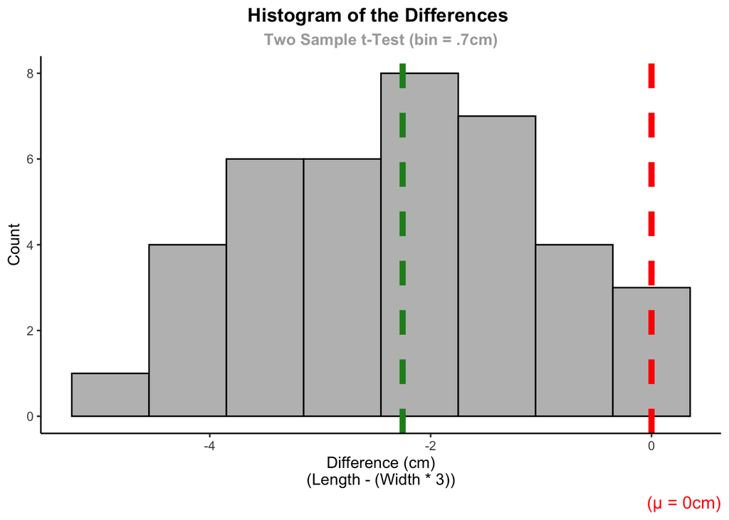

```r
# Data: add calculated column
kf = KidsFeet %>%
  mutate(
    "width3" = width * 3,
    "diff" = round(length - width3, 2)
  )

# Plot: Histogram of the differences
(
  ggplot(kf)
    + geom_histogram(aes(x=diff), binwidth=.7, color="black", fill="gray")
    + geom_vline(xintercept=mean(kf$diff), color="forestgreen", linetype="dashed", linewidth=2)
    + geom_vline(xintercept=0, color="red", linetype="dashed", linewidth=2)
    + labs(
        title="Histogram of the Differences ",
        subtitle="Two Sample t-Test (bin = .7cm)",
        caption="(µ = 0cm)",
        x="Difference (cm)\n(Length - (Width * 3))",
        y="Count"
    )
    + theme_classic()
    + theme(
        plot.title = element_text(hjust=.5, face="bold"),
        plot.subtitle = element_text(hjust=.5, face="bold", color="darkgray"),
        plot.caption = element_text(color="red", size=12)
    )
)
```

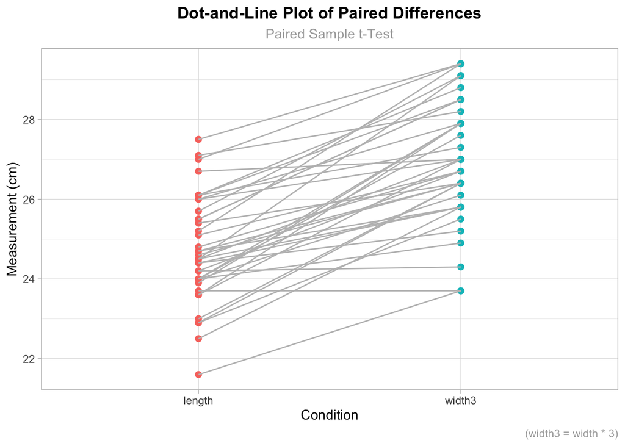

```r
# Convert the kf dataframe to long format
kf_long <- kf %>%
  mutate( id = row_number()) %>%
  select(id, length, width3) %>%
  pivot_longer(cols=c(length, width3), names_to = "condition", values_to = "value")

# Plot: Dot-and-line plot
(
  ggplot(kf_long, aes(x=condition, y=value, group=id, color=condition))
    + geom_point(size=2)
    + geom_line(color="gray")

    + labs(
        title = "Dot-and-Line Plot of Paired Differences",
        subtitle = "Paired Sample t-Test",
        caption = "(width3 = width * 3)",
        x = "Condition",
        y = "Measurement (cm)"
      )
    + theme_light()
    + theme(
        plot.title = element_text(hjust=.5, face="bold"),
        plot.subtitle = element_text(hjust=.5, color = "darkgray"),
        plot.caption = element_text(color = "darkgray"),
        legend.position = "none"
      )
)
```